# tess3r : An R Package for Population Genetics Study

Kevin Caye and Olivier François

2015-09-21

This documentation aims to present main functions of this package through two exemples. In the first exemple, we present how to use **TESS3** to find population structure and plot this structure on a map. The second exemple shows a way to use the ancestral allele frequency differentiation statistic to perform genome scan for selection. The main features of **TESS3** are illustrated using an example data set, simulated from European lines of the plant species *Arabidopsis thaliana*. More details on **tess3r** package can be found in the package documentation.

## Visualization of Ancestry Coefficients Using **TESS3**

This example describes how to use **tess3r** R package to run **TESS3** algorithm for several values of the number of ancestral populations.

```r
library(tess3r)

# Retrieve data file name
genotype.file <- system.file("extdata/Athaliana","Athaliana.geno",package = "tess3r")
coord.file <- system.file("extdata/Athaliana","Athaliana.coord",package = "tess3r")
# Read coordinate file
coord <- read.coord(coord.file)
n <- nrow(coord)

project <- tess3(input.file = genotype.file,
                input.coord = coord.file,
                K = 1:5,
                ploidy = 1,
                repetitions = 1,
                entropy = TRUE,
                percentage = 0.2,
                project = "new")
```

Then we plot a graph of the cross-entropy criterion as function of K.

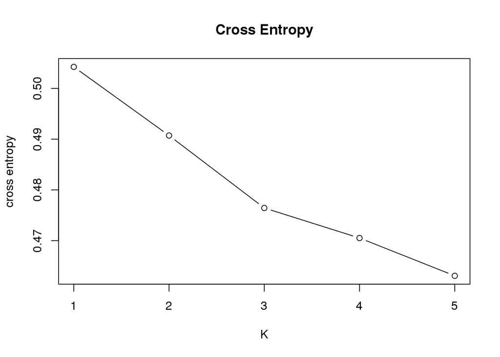

```r
###########################################
# Chose of K with cross-entropy criterion #
###########################################

cross <- sapply(1:5, function(k) { cross.entropy(project, run = 1, K = k) })
plot( 1:5, cross, main  = "Cross Entropy",type="b", xlab = "K", ylab = "cross entropy" )
```

Finally, geographic representations of ancestry coefficient maps is displayed using raster files.

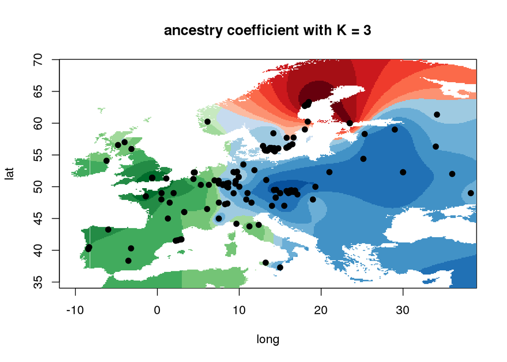

```r
################################
# Plot result on map for K = 3 #
################################

asciiFile=system.file("extdata/","lowResEurope.asc",package = "tess3r")
grid=createGridFromAsciiRaster(asciiFile)
# To display only altitudes above 0:
constraints=getConstraintsFromAsciiRaster(asciiFile,cell_value_min=0)

maps(matrix = Q( project, K = 3, run = 1 ),
     coord = coord,
     grid=grid,constraints=constraints,method="max",main="ancestry coefficient with K = 3")
```

## Genome Scan for Selection Using **TESS3**

We show here how to use **tess3r** R package to perform a genome scan for selection based on the computation of ancestral allele frequency differentiation statistics. Here **TESS3** is run with $K = 3$ ancestral populations.

```r
library(tess3r)

# Retrieve data file name
genotype.file <- system.file("extdata/Athaliana","Athaliana.geno",package = "tess3r")
coord.file <- system.file("extdata/Athaliana","Athaliana.coord",package = "tess3r")
# Read coordinate file
coord <- read.coord(coord.file)
n <- nrow(coord)

project = tess3(input.file = genotype.file,
                input.coord = coord.file,
                K = 3,
                ploidy = 1,
                repetitions = 5,
                project="new")
```

The $F_{\rm ST}$ statistics were transformed into squared $t$-scores and $p$-values using a Fisher distribution.

```r
#### Fst with TESS3
Fst = FST( project, 3, 1 )
Fst[Fst < 0.0] = 0.0

#### Convert Fst into t score
squared.t.scores = Fst*(n-3) / 2 / (1-Fst)
```

Inflation of the test statistic caused by population structure was corrected by recalibrating the $p$-values to follow a uniform distribution under the null hypothesis.

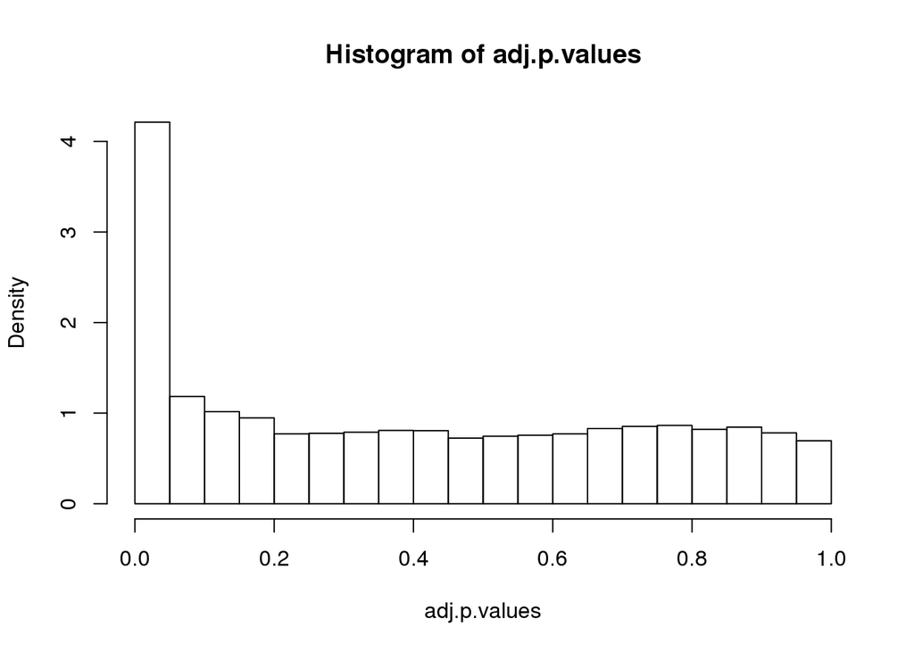

```r
#### recalibrated p-values
gif = 12.5
adj.p.values = pf( squared.t.scores/gif , df1 = 2, df2 = n-3, lower = FALSE )

hist(adj.p.values,prob=TRUE)
```

The false discovery rate was controlled using the Benjamini-Hochberg procedure.

```r
#### Benjamini Hochberg procedure
alpha = 1e-10
L = length(adj.p.values)
# return a list of candidates with an expected FDR of alpha.
w = which(sort(adj.p.values) < alpha * (1:L) / L)
candidates = order(adj.p.values)[w]
limite = max(adj.p.values[candidates])
```

Finally, candidate loci are shown above the green dashed line threshold in the Manhattan Plot.

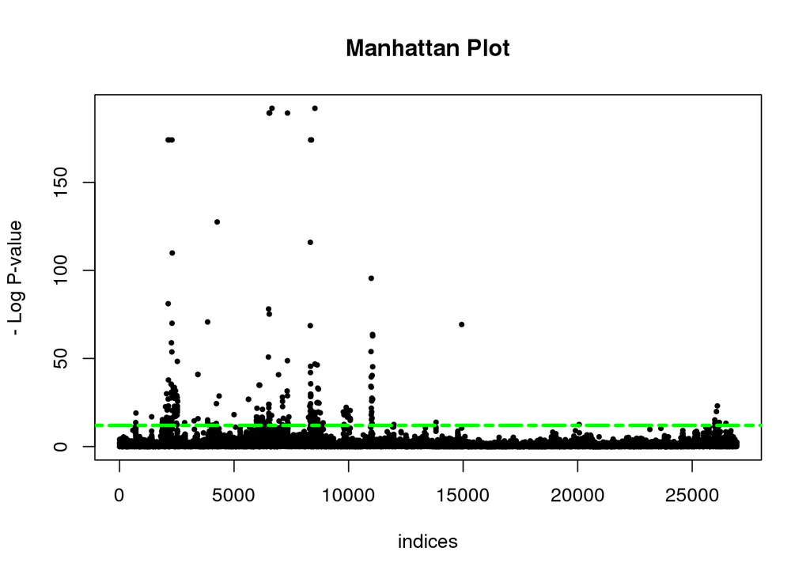

```r
#### Manhattan plot
plot( 1:length(adj.p.values),-log10(adj.p.values) ,
      main = "Manhattan Plot" ,
      xlab = "indices",
      ylab="- Log P-value",
      pch=19, cex = .5)
#add limite
abline( -log10(limite), 0, col = "green", lty = 6, lwd = 3 )
```

References

Chen, Chibiao, Eric Durand, Florence Forbes, and Olivier François. 2007. “Bayesian Clustering Algorithms Ascertaining Spatial Population Structure: A New Computer Program and a Comparison Study.” *Molecular Ecology Notes* 7 (5). Wiley Online Library: 747–56.

Durand, Eric, Flora Jay, Oscar E Gaggiotti, and Olivier François. 2009. “Spatial Inference of Admixture Proportions and Secondary Contact Zones.” *Molecular Biology and Evolution* 26 (9). SMBE: 1963–73.